# Descriptive Analysis of MOOCs Dataset

Ming-Chen Lu (mingchlu@umich.edu)

January 04, 2020

# **Introduction**

Since the launching of the first 17 HarvardX and MITx courses on the edX platform in 2012, enthusiastic learners from all over the world have benefited and satisfied their thirst for knowledge from these online learning platforms. After discovering that Harvard released the data of the first year open online courses to the public, I was curious about the impact of open online courses made to users and decided to get my hands dirty by playing the data.

# **Data**

The data comes from [HarvardX Person-Course Academic Year 2013 De-Identified dataset, version 3.0](https://doi.org/10.7910/DVN/26147) provided by Harvard Dataverse. According to the dataset description, it comprises of de-identified data from the first year (Academic Year 2013: Fall 2012, Spring 2013, and Summer 2013) of HarvardX courses on the edX platform. The data are aggregate records, and each record represents one individual’s activity in one edX course.

# **Methods**

The project applied a descriptive methodology to explore users’ behavior of open online courses based on the dataset provided by Harvard Dataverse. I primarily used graphs and plots to grasp the whole picture of the dataset.

# **Analysis**

The data contains five courses: The Ancient Greek Hero (CB22x), Introduction to Computer Science I (CS50x), Justice (ER22x), Health in Numbers: Quantitative Methods in Clinical & Public Health Research (PH207x), and Human Health and Global Environmental Change (PH278x). We first looked at the geographical distribution of registrants. The below plot shows that the United States has the most registrant (28.91%), followed by India (8.84%) and United Kingdom (3.33%). It’s also interesting to see that registrants came from five different continents of the world.

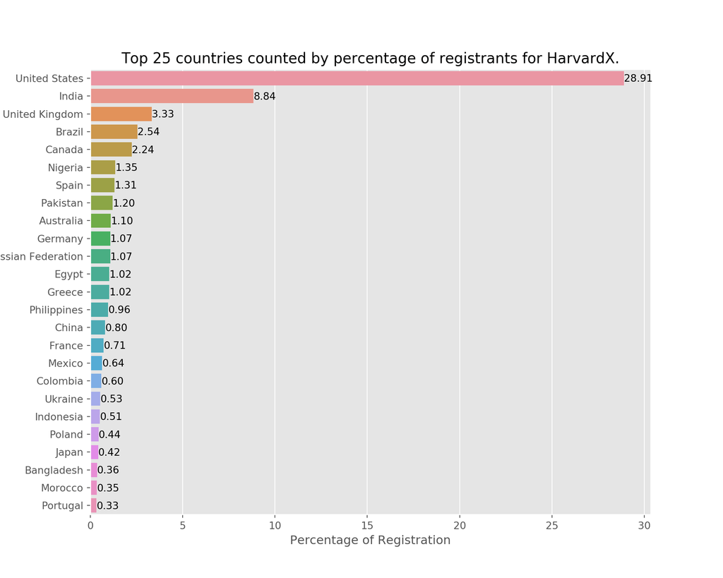

```python
# Set up: ----------------------------------------------------------------------
import pandas as pd
import numpy as np
import matplotlib.pyplot as plt
from matplotlib.ticker import PercentFormatter
import seaborn as sns
plt.style.use('ggplot')

# Read in the data: ------------------------------------------------------------
file = pd.read_csv("HXPC13_DI_v3_11-13-2019.csv")

# Data Preparation: ------------------------------------------------------------
# Split the course_id and delete roles showing all NAs
temp = file["course_id"].str.split("/", n = 2, expand = True)
file["institution"] = temp[0]
file["course"] = temp[1]
file["semester"] = temp[2]
file.drop(columns = ["course_id", "roles"], inplace = True)

# Geographical distribution of registrants: ------------------------------------
regions = pd.DataFrame(file.groupby("final_cc_cname_DI")['userid_DI']
                       .nunique(["userid_DI"])
                       .sort_values(ascending = False))
regions['pct'] =  (regions.values / regions.values.sum())*100
regions = regions[~regions.index.str.contains('Other')]

# Plot
plt.figure(figsize=(10, 8))
plt.title("Top 25 countries counted by percentage of registrants for HarvardX.")
bplot = sns.barplot(x=regions['pct'], y=regions.index)
bplot.set_xlabel('Percentage of Registration')
bplot.set_ylabel('')
for p in bplot.patches:
    width = p.get_width()
    bplot.text(width, p.get_y() + p.get_height()/2. + 0.2,
               '{:1.2f}'.format(width),
               ha="left")
```

Next, let’s look at the activity statistics for each course. The variables *viewed*, *explored*, and *certified* represent the person who accessed the courseware tab, the person who accessed at least half of the chapters in the courseware, and the person who earned a certificate respectively. All are binary variables (0/1). By observing the bar plot, among all registrants, all courses had at least half of the viewers except the course “PH278x”. However, the percentage of registrants accessing at least half of the course or earning the certificate was below 10%, except the course “PH207x”. My guesses for this phenomenon are that people lack the motivation to keep up the course or many people watched some of the chapters to suit their needs, and both causing the high drop out rate.

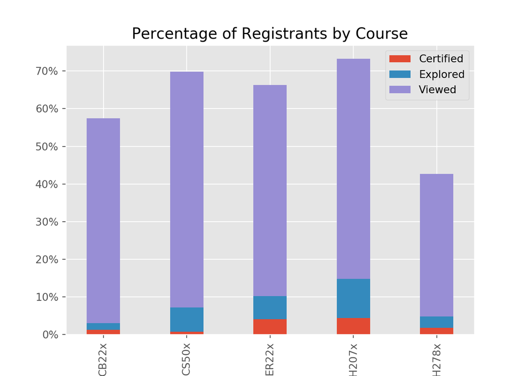

```python
# Activity Statistics: ---------------------------------------------------------
course = pd.pivot_table(file, index = ["course"],
                         values = ["viewed", "explored", "certified"],
                         aggfunc = np.sum)

# compute the percentage
cnts = file.groupby(["course"]).size()
course['Certified'] = (course['certified'].values / cnts)*100
course['Explored'] = (course['explored'].values / cnts)*100
course['Viewed'] = (course['viewed'].values / cnts)*100

# plot
p1 = course.iloc[:,3:].plot.bar(stacked=True, figsize=(7,5), width = 0.4)
#p1.set_ylim([0,100])
p1.yaxis.set_major_formatter(PercentFormatter())
p1.legend(loc = 1)
plt.title('Percentage of Registrants by Course')
#plt.xticks(rotation = 45)
plt.show()
```

The last graph shows the percentage of certificate earners with different levels of education. It appears that the majority of certificate earners are ones with bachelor’s or master’s degree.

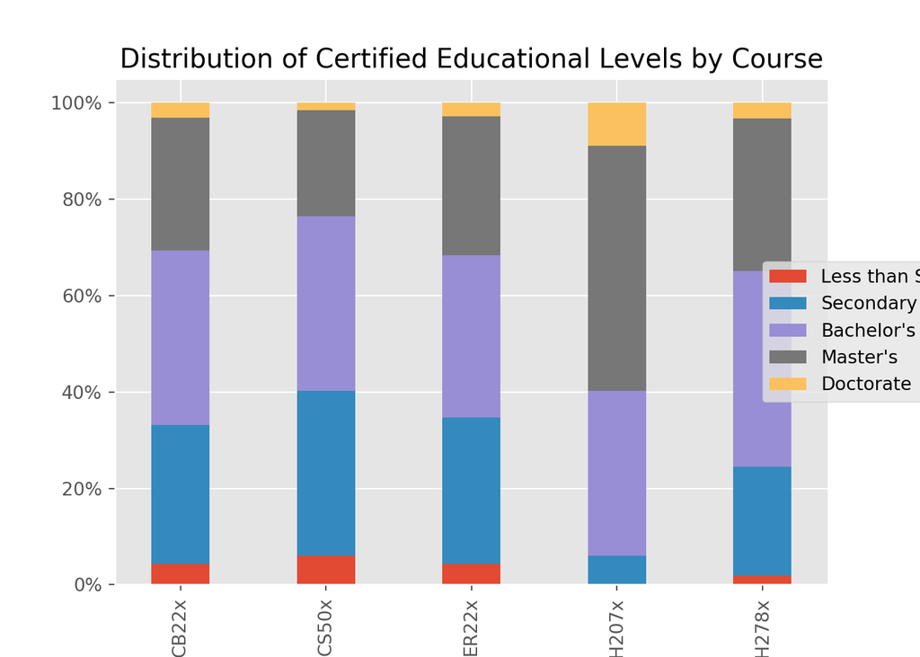

```python
# Explore users' learning activity with different educational levels: -----------
# remove the internally inconsistent records
file = file[file['incomplete_flag'] != 1]

# Extract key columns
df = file[['course', 'LoE_DI', 'explored', 'certified']]
df = df.dropna(axis = 0)

# Reorder LoE_DI
df['LoE_DI'] = ( df['LoE_DI'].astype('category').
                cat.reorder_categories(['Less than Secondary', 'Secondary',
                                        "Bachelor's", "Master's", 'Doctorate']) )

# Percentage of users' educational level by course
edu = df.groupby(['course', 'LoE_DI']).sum()
edu = edu.groupby(level=0).apply(lambda x: 100 * x / x.sum())
edu = edu.reset_index()

# Plots: --------------------------------------------------------------------------
# prepare data
pivot_edu = edu.pivot(index = 'course', columns = 'LoE_DI',
                      values = ['explored', 'certified'])

# Stacked bar plot - Certified
p3 = pivot_edu['certified'].plot.bar(stacked=True, figsize=(7,5), width = 0.4)

#p3.set_ylim([0,100])
p3.yaxis.set_major_formatter(PercentFormatter())
p3.legend(loc = 'center right', bbox_to_anchor=(1.28, 0.5))
#plt.xticks(rotation=45)
plt.title('Distribution of Certified Educational Levels by Course')
plt.show()
```

# **Summary**

From the quick analysis of the data, the most interesting question emerged to me is how users with different educational level perform in online open courses. The question affects the course design and teaching methods that could give learners whole-new learning experiences. To examine the relationship between them, a linear or regression model can be considered in the future.

# **References**

Pandas 0.15.2 documentation: https://pandas.pydata.org/pandas-docs/version/0.15/tutorials.html

Person Course Documentation: https://dataverse.harvard.edu/file.xhtml?persistentId=doi:10.7910/DVN/26147/FD5IES&version=11.2